# DAPC_Ppor_Host

## Determine how many PCs for the group Treatment

*NB! This step takes a bit of time.* By default, we perform 30 replicates, though it should be noted that for large datasets, performing large numbers of replicates may be computationally intensive.

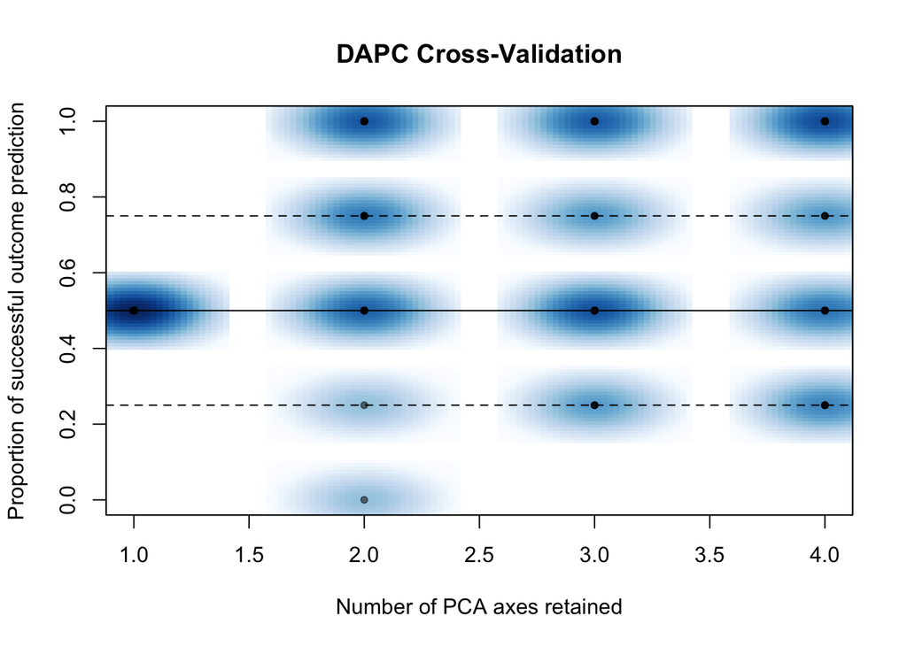

```r
# Default runs 30 replicates of cross-validation

xval <- xvalDapc(dat, meta$group, n.pca.max = 300, n.da = NULL, training.set = 0.9, result = "groupMean", center = TRUE, scale = FALSE, n.pca = NULL, n.rep = 30, xval.plot = TRUE)
```

```r
# Individual replicates appear as points, and the density of those points in different regions of the plot is displayed in blue.
```

Look for peak in the graph above.

From here, we can narrow the search by specifying the number of PC to try with n.pca and centering it around 3, and doing 100(0) replicates each.

*NB! This will take a long time ! (for 100, 1000 replicates)*

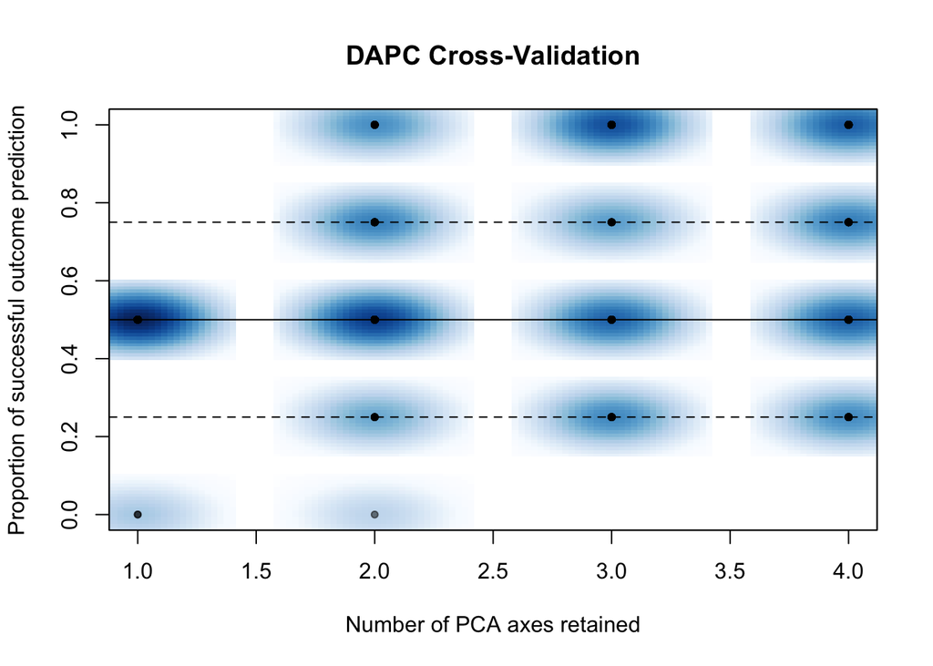

```r
xval2 <- xvalDapc(dat, meta$group, n.pca.max = 300, n.da = NULL, training.set = 0.9, result = "groupMean", center = TRUE, scale = FALSE, n.pca = 1:5, n.rep = 100, xval.plot = TRUE)
```

Based on the model validation literature, recommended to use the number of PCs associated with the lowest RMSE as the ‘optimum’ n.pca in the DAPC analysis. - RMSE = associated root mean squared error

While the number of PCs associated with the highest mean success may be associated with the lowest MSE, this is not always the case.

```r
#names(xval2)
xval2
```

```
## $`Cross-Validation Results`
##     n.pca success
## 1       1    0.50
## 2       1    0.50
## 3       1    0.50
## 4       1    0.50
## 5       1    0.50
## 6       1    0.50
## 7       1    0.50
## 8       1    0.50
## 9       1    0.50
## 10      1    0.50
## 11      1    0.50
## 12      1    0.50
## 13      1    0.50
```

[output cut: 435 more lines]

Mean Successful Assignment by Number of PCs of PCA 3 0.7025

Number of PCs Achieving Highest Mean Success 3

Root Mean Squared Error by Number of PCs of PCA 3 0.4160829

Number of PCs Achieving Lowest MSE 3

DAPC - n.pca: 3 first PCs of PCA used - n.da: 1 discriminant functions saved - var (proportion of conserved variance): 0.786

```r
xval2$DAPC # this should be the same output as dp2 below
```

```
##  #################################################
##  # Discriminant Analysis of Principal Components #
##  #################################################
## class: dapc
## $call: dapc.data.frame(x = x, grp = grp, n.pca = n.pca, n.da = n.da)
##
## $n.pca: 3 first PCs of PCA used
## $n.da: 1 discriminant functions saved
## $var (proportion of conserved variance): 0.786
##
## $eig (eigenvalues): 6.661  vector    length content
## 1 $eig      1      eigenvalues
## 2 $grp      9      prior group assignment
## 3 $prior    2      prior group probabilities
## 4 $assign   9      posterior group assignment
## 5 $pca.cent 7397   centring vector of PCA
## 6 $pca.norm 7397   scaling vector of PCA
## 7 $pca.eig  8      eigenvalues of PCA
##
##   data.frame    nrow ncol content
## 1 $tab          9    3    retained PCs of PCA
## 2 $means        2    3    group means
## 3 $loadings     3    1    loadings of variables
## 4 $ind.coord    9    1    coordinates of individuals (principal components)
## 5 $grp.coord    2    1    coordinates of groups
## 6 $posterior    9    2    posterior membership probabilities
## 7 $pca.loadings 7397 3    PCA loadings of original variables
## 8 $var.contr    7397 1    contribution of original variables
```

# Graph of cumulated variance

Unlike k-means, DAPC can benefit from not using too many PCs. Indeed, retaining too many components with respect to the number of individuals can lead to over-fitting and unstability in the membership probabilities returned by the method.

```r
# *** Need to run this next line - it's interactive - so it does not knit***
#var.explained.pca <- dapc(dat, meta$group)

# ! INTERACTIVE. Open Console !
#  Choose the number PCs to retain (>=1):
#3
#  Choose the number discriminant functions to retain (>=1):
#1
```

*Discriminant analysis eigenvalues* Eigenvalues correspond to the ratio of the variance between groups over the variance within groups for each discriminant function. The method displays a barplot of eigenvalues for the discriminant analysis, asking for a number of discriminant functions to retain (unless argument n.da is provided). For small number of clusters, all eigenvalues can be retained since all discriminant functions can be examined without diffculty. Whenever more (say, tens of) clusters are analysed, it is likely that the first few dimensions will carry more information than the others, and only those can then be retained and interpreted.

The Discriminant Analysis of Principal Components (DAPC) is designed to investigate the genetic structure of biological populations. This multivariate method consists in a two-steps procedure. - First, genetic data are transformed (centred, possibly scaled) and submitted to a Principal Component Analysis (PCA). - Second, principal components of PCA are submitted to a Linear Discriminant Analysis (LDA).

A trivial matrix operation allows to express discriminant functions as linear combination of alleles, therefore allowing one to compute allele contributions.

## Establish Discriminant function for the group Treatment

```r
dp2 = dapc(dat, meta$group, n.pca = 3, n.da = 1)
dp2
```

```
##  #################################################
##  # Discriminant Analysis of Principal Components #
##  #################################################
## class: dapc
## $call: dapc.data.frame(x = dat, grp = meta$group, n.pca = 3, n.da = 1)
##
## $n.pca: 3 first PCs of PCA used
## $n.da: 1 discriminant functions saved
## $var (proportion of conserved variance): 0.786
##
## $eig (eigenvalues): 6.661  vector    length content
## 1 $eig      1      eigenvalues
## 2 $grp      9      prior group assignment
## 3 $prior    2      prior group probabilities
## 4 $assign   9      posterior group assignment
## 5 $pca.cent 7397   centring vector of PCA
## 6 $pca.norm 7397   scaling vector of PCA
## 7 $pca.eig  8      eigenvalues of PCA
##
##   data.frame    nrow ncol content
## 1 $tab          9    3    retained PCs of PCA
## 2 $means        2    3    group means
## 3 $loadings     3    1    loadings of variables
## 4 $ind.coord    9    1    coordinates of individuals (principal components)
## 5 $grp.coord    2    1    coordinates of groups
## 6 $posterior    9    2    posterior membership probabilities
## 7 $pca.loadings 7397 3    PCA loadings of original variables
## 8 $var.contr    7397 1    contribution of original variables
```

## scatter plot

*Only used 1 discriminant function so cannot make the scatter plot as per other species*

```r
scatter <- scatter(dp2, cex = 1.5, legend = TRUE,
        clabel = FALSE, posi.leg = "topright",
        cleg = 0.9, xax = 1, yax = 2, col = c("dodgerblue", "gold2", "#163343", "firebrick", "forestgreen", "bisque3")) #inset.solid = 1,
```

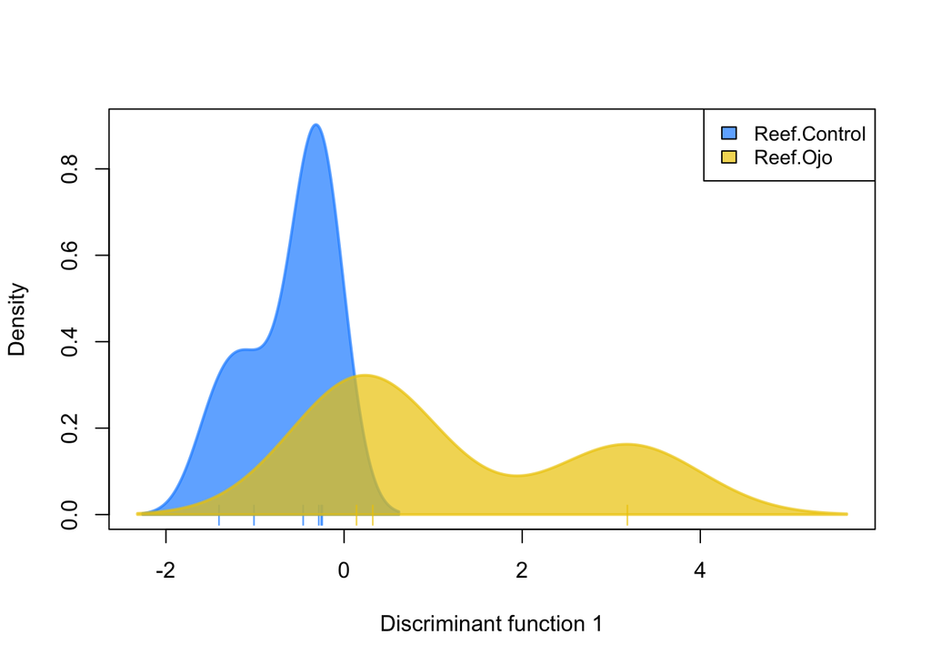

```r
#posi.pca = "bottomleft",
# , posi.inset = "bottomleft" # not working ?
```

save plot

```r
# save plot
pdf("Ppor_Host_DAPC_scatter.pdf")

scatter <- scatter(dp2, cex = 1.5, legend = TRUE,
        clabel = FALSE, posi.leg = "topright",
        cleg = 0.9, xax = 1, yax = 2, col = c("dodgerblue", "gold2", "#163343", "firebrick", "forestgreen", "bisque3")) #inset.solid = 1,
#posi.pca = "bottomleft",
# , posi.inset = "bottomleft" # not working ?

dev.off()
```

Note that scatter can also represent a single discriminant function, which is especially useful when only one of these has been retained (e.g. in the case k = 2). This is achieved by plotting the densities of individuals on a given discriminant function with different colors for different groups:

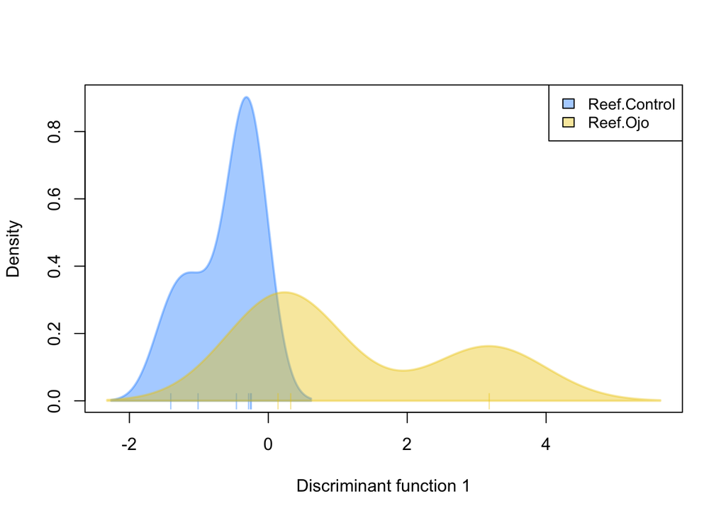

```r
scatter(dp2,1,1, bg="white", scree.da=FALSE, legend=TRUE, solid=.4, col = c("dodgerblue", "gold2", "#163343", "firebrick", "forestgreen", "bisque3"), cleg = 0.9)
```

save plot

```r
# save plot
pdf("Ppor_Host_DAPC_density.pdf")

scatter(dp2,1,1, bg="white", scree.da=FALSE, legend=TRUE, solid=.4, col = c("dodgerblue", "gold2", "#163343", "firebrick", "forestgreen", "bisque3"), cleg = 0.9)

dev.off()
```

Alternate colors

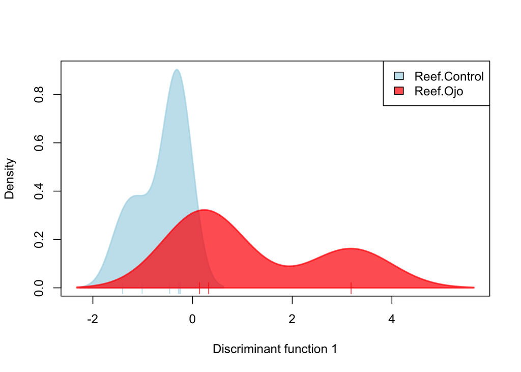

```r
mycol=c("lightblue", "red", "orange", "grey", "yellow", "light green")
scatter(dp2,1,1, scree.da = FALSE, bg = "white", col = mycol, cex = 1.5, legend = TRUE, posi.leg = "topright")
```

```r
# assign.per.pop
# indicates the proportions of successful reassignment (based on the discriminant functions) # of individuals to their original clusters.
# Large values indicate clear-cut clusters, while low values suggest admixed groups.

summary(dp2)
```

```
## $n.dim
## [1] 1
##
## $n.pop
## [1] 2
##
## $assign.prop
## [1] 0.7777778
##
## $assign.per.pop
## Reef.Control     Reef.Ojo
##    1.0000000    0.3333333
##
## $prior.grp.size
##
## Reef.Control     Reef.Ojo
##            6            3
##
## $post.grp.size
##
## Reef.Control     Reef.Ojo
##            8            1
```

```r
# This information can also be visualized using assignplot()
```

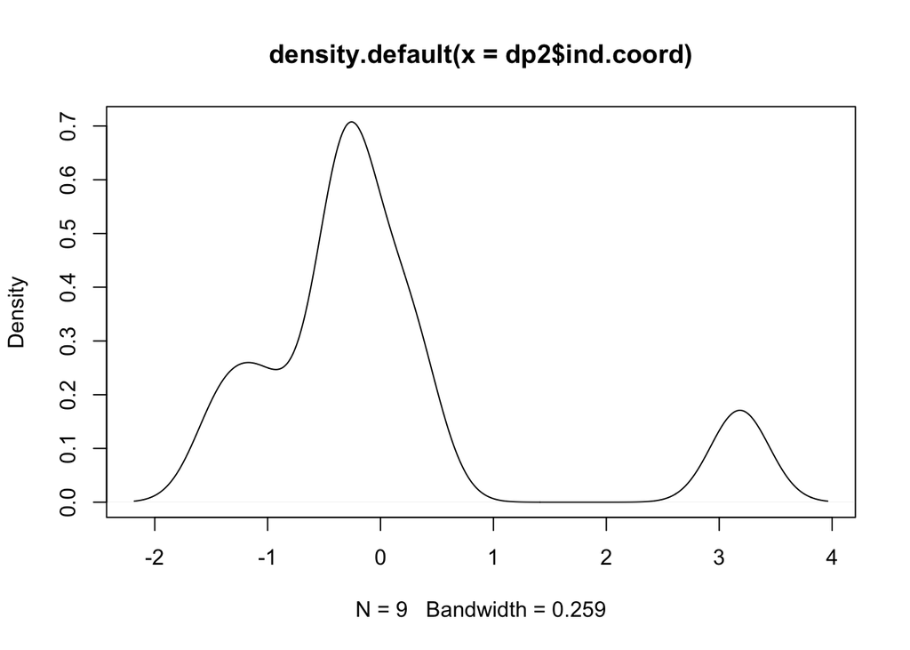

```r
plot(density(dp2$ind.coord))
```

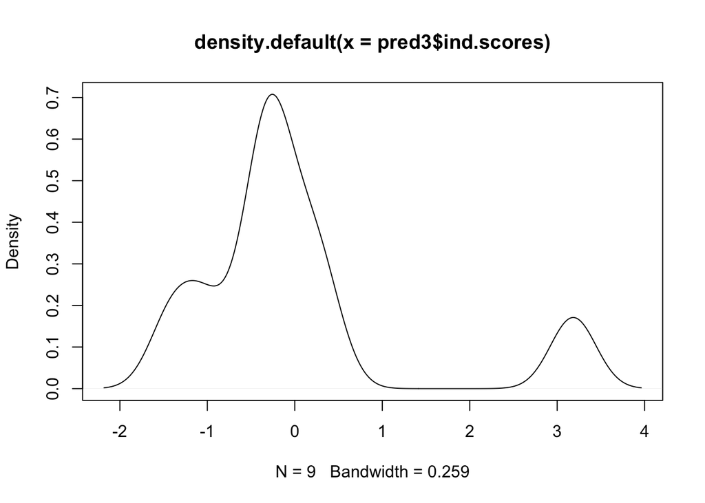

```r
# predict.dapc: predicts group memberships based on DAPC results
pred3 = predict.dapc(dp2)
plot(density(pred3$ind.scores))
```

Such figure is particularly useful when prior biological groups are used, as one may infer admixed or misclassiffied individuals.

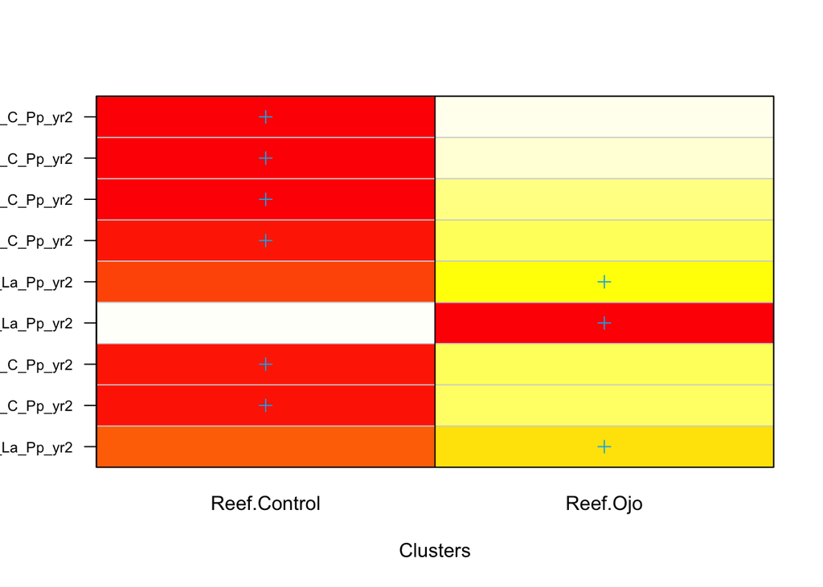

```r
assignplot(dp2)
```

Note that this information can also be plotted in a STRUCTURE-like (!) way using compoplot. We can plot information of all individuals to have a global picture of the clusters composition.

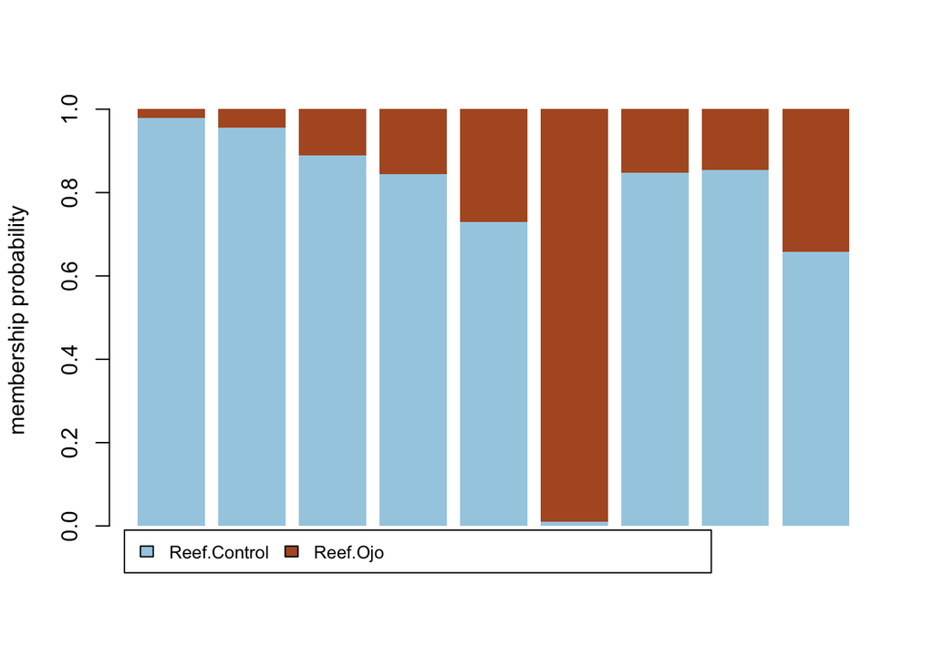

```r
compoplot(dp2)
```

DAPC: - explore structure of populations based on PCA and DA without making assumptions of panmixia. - this technique provides a robust alternative to Bayesian clustering methods like STRUCTURE (Pritchard et al., 2000) that should not be used for clonal or partially clonal populations. - DAPC analysis is inherently interactive and cannot be scripted a priori. (Refer to the vignette written by Thibaut Jombart for a more interactive analysis.)

**In DAPC, discriminant functions are linear combinations of variables (principal components of PCA) which optimize the separation of individuals into pre-defined groups.**

Based on the retained discriminant functions, it is possible to derive group membership probabilities, which can be interpreted in order to assess how clear-cut or admixed the clusters are.

In attempting to summarise high-dimensional data in a small number of meaningful discriminant functions, DAPC must manage a trade-offs. If too few PCs (with respect to the number of individuals) are retained, useful information will be excluded from the analysis, and the resultant model will not be informative enough to accurately discriminate between groups.

By contrast, if too many PCs are retained, this will have a destabilising effect on the coefficients extimated, leading to problems of overfit. In such cases, the model is able to describe all of the data in such detail that it becomes flexible enough to discriminate almost perfectly between any possible clusters. As a result, membership probabilities can become drastically inflated for the best-fitting cluster, resulting in apparent perfect discrimination. At the same time, however, the excessively complex model loses its ability to generalise to new or unseen data, as reflected in a loss of predictive capacity.

–> DAPC requires enough PCs to secure a space with sufficient power of discrimination but must also avoid retaining too many dimensions that lead to over-fitting

For reporting in manuscript:

*See Miller et al. 2020*

Box 2: Recommended standard reporting for DAPC analyses Our literature review of 263 empirical studies showed that many did not report run parameters necessary for transparency and rateability of analyses. In addition, based on those studies which did report such parameters, it was clear that no “standard operating procedure” has crystalized among researchers applying this method. Therefore, we developed the following list of parameters which should be reported in all DAPC analyses:

1. Explicitly state the clusters or clustering method used: were groups defined a priori or determined de novo using find.clusters()?
2. State how optimal number of K was chosen: when find.clusters() is used, how was the optimal number of clusters (K) chosen (e.g., lowest point of BIC graph or automated detection)?
3. Include documentation for selection of K: when using BIC, include the BIC plot or values for each K.
4. State the method used to determine how many PCs to retain: often a-score or xval; given that there is no “preferred” method when determining the number of PCs retained, including this data this is especially important for repeatability.
5. State the final number of PCs applied: this can appear either in the main text or figure legend showing the DAPC plot; inclusion of these values is essential for repeatability of the results presented.

Example of minimum adequate reporting

Methods: DAPC analyses were conducted twice to examine the influence of a priori groupings on the results. In the first analysis, sampling locations were used as a priori groups. In the second analysis, the find.clusters() function was used to determine the number of groups (K) de novo, with optimal K selected as that with the lowest BIC value. For both analyses, the optimal number of PCs to use in the DAPC was determined using the optim.a.score() command.

Results: when sampling locations were used as a priori groups, the optimal number of PCs retained were Y. Without predefined groups, the optimal K was found to be W (see Supplementary Fig. Q for BIC plot), and the optimal number of PCs retained for analysis were Z.